# Risk Factor Analysis

## Outcome Variable

**Outcome Variable:** stunted

## Predictor Variables

**Intervention Variable:** tr

**Adjustment Set:**

unadjusted

## Stratifying Variables

The analysis was stratified on these variable(s):

- agecat
- studyid
- country
- intXgagebrth

## Data Summary

| agecat | studyid | country | intXgagebrth | stunted | n_cell | n |
| --- | --- | --- | --- | --- | --- | --- |
| Birth | iLiNS_DYADM_LNS | MALAWI | Full or late term_Birth | 0 | 0 | 1 |
| Birth | iLiNS_DYADM_LNS | MALAWI | Full or late term_Birth | 1 | 1 | 1 |
| Birth | ki1000304b-SAS-CompFeed | INDIA | Preterm_Birth | 0 | 99 | 135 |
| Birth | ki1000304b-SAS-CompFeed | INDIA | Preterm_Birth | 1 | 36 | 135 |
| Birth | ki1000304b-SAS-CompFeed | INDIA | Early term_Birth | 0 | 7 | 9 |
| Birth | ki1000304b-SAS-CompFeed | INDIA | Early term_Birth | 1 | 2 | 9 |
| Birth | ki1119695-PROBIT | BELARUS | Full or late term_Birth | 0 | 7090 | 7095 |
| Birth | ki1119695-PROBIT | BELARUS | Full or late term_Birth | 1 | 5 | 7095 |
| Birth | ki1119695-PROBIT | BELARUS | Preterm_Birth | 0 | 458 | 472 |
| Birth | ki1119695-PROBIT | BELARUS | Preterm_Birth | 1 | 14 | 472 |
| Birth | ki1119695-PROBIT | BELARUS | Early term_Birth | 0 | 6303 | 6317 |
| Birth | ki1119695-PROBIT | BELARUS | Early term_Birth | 1 | 14 | 6317 |
| Birth | ki1135781-COHORTS | GUATEMALA | Full or late term_Birth | 0 | 330 | 341 |
| Birth | ki1135781-COHORTS | GUATEMALA | Full or late term_Birth | 1 | 11 | 341 |
| Birth | ki1135781-COHORTS | GUATEMALA | Preterm_Birth | 0 | 82 | 95 |
| Birth | ki1135781-COHORTS | GUATEMALA | Preterm_Birth | 1 | 13 | 95 |
| Birth | ki1135781-COHORTS | GUATEMALA | Early term_Birth | 0 | 170 | 181 |
| Birth | ki1135781-COHORTS | GUATEMALA | Early term_Birth | 1 | 11 | 181 |
| Birth | ki1148112-iLiNS-DYAD-M | MALAWI | Full or late term_Birth | 0 | 0 | 1 |
| Birth | ki1148112-iLiNS-DYAD-M | MALAWI | Full or late term_Birth | 1 | 1 | 1 |
| Birth | kiGH5241-JiVitA-3 | BANGLADESH | Full or late term_Birth | 0 | 14864 | 19084 |
| Birth | kiGH5241-JiVitA-3 | BANGLADESH | Full or late term_Birth | 1 | 4220 | 19084 |
| Birth | kiGH5241-JiVitA-3 | BANGLADESH | Preterm_Birth | 0 | 3614 | 7548 |
| Birth | kiGH5241-JiVitA-3 | BANGLADESH | Preterm_Birth | 1 | 3934 | 7548 |
| Birth | kiGH5241-JiVitA-3 | BANGLADESH | Early term_Birth | 0 | 6572 | 10236 |
| Birth | kiGH5241-JiVitA-3 | BANGLADESH | Early term_Birth | 1 | 3664 | 10236 |
| 6 months | iLiNS_DYADM_LNS | MALAWI | Full or late term_6 months | 0 | 359 | 442 |
| 6 months | iLiNS_DYADM_LNS | MALAWI | Full or late term_6 months | 1 | 83 | 442 |
| 6 months | iLiNS_DYADM_LNS | MALAWI | Preterm_6 months | 0 | 25 | 45 |
| 6 months | iLiNS_DYADM_LNS | MALAWI | Preterm_6 months | 1 | 20 | 45 |

[output cut: 72 more lines]

The following strata were considered:

- agecat: 24 months, studyid: iLiNS_DYADM_LNS, country: MALAWI, intXgagebrth: Early term_24 months
- agecat: 24 months, studyid: iLiNS_DYADM_LNS, country: MALAWI, intXgagebrth: Full or late term_24 months
- agecat: 24 months, studyid: iLiNS_DYADM_LNS, country: MALAWI, intXgagebrth: Preterm_24 months
- agecat: 24 months, studyid: ki1066203-TanzaniaChild2, country: TANZANIA, UNITED REPUBLIC OF, intXgagebrth: Early term_24 months
- agecat: 24 months, studyid: ki1066203-TanzaniaChild2, country: TANZANIA, UNITED REPUBLIC OF, intXgagebrth: Full or late term_24 months
- agecat: 24 months, studyid: ki1119695-PROBIT, country: BELARUS, intXgagebrth: Early term_24 months
- agecat: 24 months, studyid: ki1119695-PROBIT, country: BELARUS, intXgagebrth: Full or late term_24 months
- agecat: 24 months, studyid: ki1119695-PROBIT, country: BELARUS, intXgagebrth: Preterm_24 months
- agecat: 24 months, studyid: ki1135781-COHORTS, country: GUATEMALA, intXgagebrth: Early term_24 months
- agecat: 24 months, studyid: ki1135781-COHORTS, country: GUATEMALA, intXgagebrth: Full or late term_24 months
- agecat: 24 months, studyid: ki1135781-COHORTS, country: GUATEMALA, intXgagebrth: Preterm_24 months
- agecat: 24 months, studyid: ki1148112-iLiNS-DYAD-M, country: MALAWI, intXgagebrth: Early term_24 months
- agecat: 24 months, studyid: ki1148112-iLiNS-DYAD-M, country: MALAWI, intXgagebrth: Full or late term_24 months
- agecat: 24 months, studyid: ki1148112-iLiNS-DYAD-M, country: MALAWI, intXgagebrth: Preterm_24 months
- agecat: 24 months, studyid: kiGH5241-JiVitA-3, country: BANGLADESH, intXgagebrth: Early term_24 months
- agecat: 24 months, studyid: kiGH5241-JiVitA-3, country: BANGLADESH, intXgagebrth: Full or late term_24 months
- agecat: 24 months, studyid: kiGH5241-JiVitA-3, country: BANGLADESH, intXgagebrth: Preterm_24 months
- agecat: 6 months, studyid: iLiNS_DYADM_LNS, country: MALAWI, intXgagebrth: Early term_6 months
- agecat: 6 months, studyid: iLiNS_DYADM_LNS, country: MALAWI, intXgagebrth: Full or late term_6 months
- agecat: 6 months, studyid: iLiNS_DYADM_LNS, country: MALAWI, intXgagebrth: Preterm_6 months
- agecat: 6 months, studyid: ki1000304b-SAS-CompFeed, country: INDIA, intXgagebrth: Early term_6 months
- agecat: 6 months, studyid: ki1000304b-SAS-CompFeed, country: INDIA, intXgagebrth: Full or late term_6 months
- agecat: 6 months, studyid: ki1000304b-SAS-CompFeed, country: INDIA, intXgagebrth: Preterm_6 months
- agecat: 6 months, studyid: ki1066203-TanzaniaChild2, country: TANZANIA, UNITED REPUBLIC OF, intXgagebrth: Early term_6 months
- agecat: 6 months, studyid: ki1066203-TanzaniaChild2, country: TANZANIA, UNITED REPUBLIC OF, intXgagebrth: Full or late term_6 months
- agecat: 6 months, studyid: ki1066203-TanzaniaChild2, country: TANZANIA, UNITED REPUBLIC OF, intXgagebrth: Preterm_6 months
- agecat: 6 months, studyid: ki1119695-PROBIT, country: BELARUS, intXgagebrth: Early term_6 months
- agecat: 6 months, studyid: ki1119695-PROBIT, country: BELARUS, intXgagebrth: Full or late term_6 months
- agecat: 6 months, studyid: ki1119695-PROBIT, country: BELARUS, intXgagebrth: Preterm_6 months
- agecat: 6 months, studyid: ki1135781-COHORTS, country: GUATEMALA, intXgagebrth: Early term_6 months
- agecat: 6 months, studyid: ki1135781-COHORTS, country: GUATEMALA, intXgagebrth: Full or late term_6 months
- agecat: 6 months, studyid: ki1135781-COHORTS, country: GUATEMALA, intXgagebrth: Preterm_6 months
- agecat: 6 months, studyid: ki1148112-iLiNS-DYAD-M, country: MALAWI, intXgagebrth: Early term_6 months
- agecat: 6 months, studyid: ki1148112-iLiNS-DYAD-M, country: MALAWI, intXgagebrth: Full or late term_6 months
- agecat: 6 months, studyid: ki1148112-iLiNS-DYAD-M, country: MALAWI, intXgagebrth: Preterm_6 months
- agecat: 6 months, studyid: kiGH5241-JiVitA-3, country: BANGLADESH, intXgagebrth: Early term_6 months
- agecat: 6 months, studyid: kiGH5241-JiVitA-3, country: BANGLADESH, intXgagebrth: Full or late term_6 months
- agecat: 6 months, studyid: kiGH5241-JiVitA-3, country: BANGLADESH, intXgagebrth: Preterm_6 months
- agecat: Birth, studyid: iLiNS_DYADM_LNS, country: MALAWI, intXgagebrth: Full or late term_Birth
- agecat: Birth, studyid: ki1000304b-SAS-CompFeed, country: INDIA, intXgagebrth: Early term_Birth
- agecat: Birth, studyid: ki1000304b-SAS-CompFeed, country: INDIA, intXgagebrth: Preterm_Birth
- agecat: Birth, studyid: ki1119695-PROBIT, country: BELARUS, intXgagebrth: Early term_Birth
- agecat: Birth, studyid: ki1119695-PROBIT, country: BELARUS, intXgagebrth: Full or late term_Birth
- agecat: Birth, studyid: ki1119695-PROBIT, country: BELARUS, intXgagebrth: Preterm_Birth
- agecat: Birth, studyid: ki1135781-COHORTS, country: GUATEMALA, intXgagebrth: Early term_Birth
- agecat: Birth, studyid: ki1135781-COHORTS, country: GUATEMALA, intXgagebrth: Full or late term_Birth
- agecat: Birth, studyid: ki1135781-COHORTS, country: GUATEMALA, intXgagebrth: Preterm_Birth
- agecat: Birth, studyid: ki1148112-iLiNS-DYAD-M, country: MALAWI, intXgagebrth: Full or late term_Birth
- agecat: Birth, studyid: kiGH5241-JiVitA-3, country: BANGLADESH, intXgagebrth: Early term_Birth
- agecat: Birth, studyid: kiGH5241-JiVitA-3, country: BANGLADESH, intXgagebrth: Full or late term_Birth
- agecat: Birth, studyid: kiGH5241-JiVitA-3, country: BANGLADESH, intXgagebrth: Preterm_Birth

### Dropped Strata

Some strata were dropped due to rare outcomes:

- agecat: Birth, studyid: iLiNS_DYADM_LNS, country: MALAWI, intXgagebrth: Full or late term_Birth
- agecat: Birth, studyid: ki1000304b-SAS-CompFeed, country: INDIA, intXgagebrth: Early term_Birth
- agecat: Birth, studyid: ki1148112-iLiNS-DYAD-M, country: MALAWI, intXgagebrth: Full or late term_Birth
- agecat: 6 months, studyid: ki1000304b-SAS-CompFeed, country: INDIA, intXgagebrth: Full or late term_6 months
- agecat: 24 months, studyid: iLiNS_DYADM_LNS, country: MALAWI, intXgagebrth: Preterm_24 months
- agecat: 24 months, studyid: iLiNS_DYADM_LNS, country: MALAWI, intXgagebrth: Early term_24 months
- agecat: 24 months, studyid: ki1066203-TanzaniaChild2, country: TANZANIA, UNITED REPUBLIC OF, intXgagebrth: Full or late term_24 months
- agecat: 24 months, studyid: ki1066203-TanzaniaChild2, country: TANZANIA, UNITED REPUBLIC OF, intXgagebrth: Early term_24 months
- agecat: 24 months, studyid: ki1119695-PROBIT, country: BELARUS, intXgagebrth: Preterm_24 months
- agecat: 24 months, studyid: ki1135781-COHORTS, country: GUATEMALA, intXgagebrth: Preterm_24 months
- agecat: 24 months, studyid: ki1135781-COHORTS, country: GUATEMALA, intXgagebrth: Early term_24 months
- agecat: 24 months, studyid: ki1148112-iLiNS-DYAD-M, country: MALAWI, intXgagebrth: Preterm_24 months
- agecat: 24 months, studyid: kiGH5241-JiVitA-3, country: BANGLADESH, intXgagebrth: Full or late term_24 months
- agecat: 24 months, studyid: kiGH5241-JiVitA-3, country: BANGLADESH, intXgagebrth: Preterm_24 months
- agecat: 24 months, studyid: kiGH5241-JiVitA-3, country: BANGLADESH, intXgagebrth: Early term_24 months

## Methods Detail

We’re interested in the causal parameters $E[Y_a]$ for all values of $a \in \mathcal{A}$. These parameters represent the mean outcome if, possibly contrary to fact, we intervened to set all units to have $A=a$. Under the randomization and positivity assumptions, these are identified by the statistical parameters $\psi_a=E_W[E_{Y|A,W}(Y|A=a,W)]$. In addition, we’re interested in the mean of $Y$, $E[Y]$ under no intervention (the observed mean). We will estimate these parameters by using SuperLearner to fit the relevant likelihood factors – $E_{Y|A,W}(Y|A=a,W)$ and $p(A=a|W)$, and then updating our likelihood fit using a joint TMLE.

For unadjusted analyses ($W=\{\}$), initial likelihoods were estimated using Lrnr_glm to estimate the simple $E(Y|A)$ and Lrnr_mean to estimate $p(A)$. For adjusted analyses, a small library containing Lrnr_glmnet, Lrnr_xgboost, and Lrnr_mean was used.

Having estimated these parameters, we will then use the delta method to estimate relative risks and attributable risks relative to a prespecified baseline level of $A$.

# Results Detail

## Results Plots

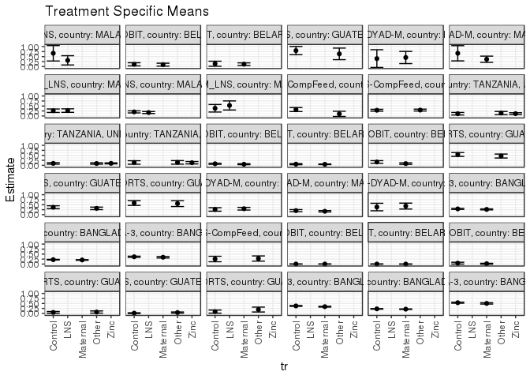

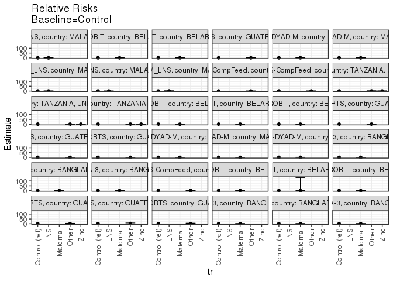

[figure not shown]

[figure not shown]

## Results Table

### Parameter: TSM

| agecat | studyid | country | intXgagebrth | intervention_level | baseline_level | estimate | ci_lower | ci_upper |
| --- | --- | --- | --- | --- | --- | --- | --- | --- |
| Birth | ki1000304b-SAS-CompFeed | INDIA | Preterm_Birth | Control | NA | 0.2539683 | 0.1168901 | 0.3910464 |
| Birth | ki1000304b-SAS-CompFeed | INDIA | Preterm_Birth | Other | NA | 0.2777778 | 0.1478153 | 0.4077402 |
| Birth | ki1119695-PROBIT | BELARUS | Full or late term_Birth | Control | NA | 0.0012516 | 0.0001623 | 0.0023409 |
| Birth | ki1119695-PROBIT | BELARUS | Full or late term_Birth | Maternal | NA | 0.0002565 | -0.0013982 | 0.0019111 |
| Birth | ki1119695-PROBIT | BELARUS | Preterm_Birth | Control | NA | 0.0456853 | 0.0001878 | 0.0911828 |
| Birth | ki1119695-PROBIT | BELARUS | Preterm_Birth | Maternal | NA | 0.0181818 | -0.0035308 | 0.0398944 |
| Birth | ki1119695-PROBIT | BELARUS | Early term_Birth | Control | NA | 0.0023627 | 0.0009243 | 0.0038010 |
| Birth | ki1119695-PROBIT | BELARUS | Early term_Birth | Maternal | NA | 0.0020471 | 0.0003969 | 0.0036973 |
| Birth | ki1135781-COHORTS | GUATEMALA | Full or late term_Birth | Control | NA | 0.0142857 | -0.0053999 | 0.0339713 |
| Birth | ki1135781-COHORTS | GUATEMALA | Full or late term_Birth | Other | NA | 0.0447761 | 0.0161433 | 0.0734089 |
| Birth | ki1135781-COHORTS | GUATEMALA | Preterm_Birth | Control | NA | 0.0925926 | 0.0148716 | 0.1703136 |
| Birth | ki1135781-COHORTS | GUATEMALA | Preterm_Birth | Other | NA | 0.1951220 | 0.0731747 | 0.3170692 |
| Birth | ki1135781-COHORTS | GUATEMALA | Early term_Birth | Control | NA | 0.0520833 | 0.0075126 | 0.0966541 |
| Birth | ki1135781-COHORTS | GUATEMALA | Early term_Birth | Other | NA | 0.0705882 | 0.0159858 | 0.1251907 |
| Birth | kiGH5241-JiVitA-3 | BANGLADESH | Full or late term_Birth | Control | NA | 0.2291484 | 0.2149743 | 0.2433225 |
| Birth | kiGH5241-JiVitA-3 | BANGLADESH | Full or late term_Birth | Maternal | NA | 0.2137986 | 0.2009900 | 0.2266073 |
| Birth | kiGH5241-JiVitA-3 | BANGLADESH | Preterm_Birth | Control | NA | 0.5371007 | 0.5116062 | 0.5625952 |
| Birth | kiGH5241-JiVitA-3 | BANGLADESH | Preterm_Birth | Maternal | NA | 0.5025877 | 0.4702814 | 0.5348940 |
| Birth | kiGH5241-JiVitA-3 | BANGLADESH | Early term_Birth | Control | NA | 0.3760651 | 0.3534339 | 0.3986962 |
| Birth | kiGH5241-JiVitA-3 | BANGLADESH | Early term_Birth | Maternal | NA | 0.3395110 | 0.3180192 | 0.3610029 |
| 6 months | iLiNS_DYADM_LNS | MALAWI | Full or late term_6 months | Control | NA | 0.2035398 | 0.1509874 | 0.2560922 |
| 6 months | iLiNS_DYADM_LNS | MALAWI | Full or late term_6 months | LNS | NA | 0.1712963 | 0.1209941 | 0.2215985 |
| 6 months | iLiNS_DYADM_LNS | MALAWI | Preterm_6 months | Control | NA | 0.3846154 | 0.1954995 | 0.5737313 |
| 6 months | iLiNS_DYADM_LNS | MALAWI | Preterm_6 months | LNS | NA | 0.5263158 | 0.2992672 | 0.7533644 |
| 6 months | iLiNS_DYADM_LNS | MALAWI | Early term_6 months | Control | NA | 0.2626263 | 0.1757194 | 0.3495331 |
| 6 months | iLiNS_DYADM_LNS | MALAWI | Early term_6 months | LNS | NA | 0.2680412 | 0.1796688 | 0.3564137 |
| 6 months | ki1000304b-SAS-CompFeed | INDIA | Preterm_6 months | Control | NA | 0.2857143 | 0.2399219 | 0.3315067 |
| 6 months | ki1000304b-SAS-CompFeed | INDIA | Preterm_6 months | Other | NA | 0.2939189 | 0.2472513 | 0.3405865 |
| 6 months | ki1000304b-SAS-CompFeed | INDIA | Early term_6 months | Control | NA | 0.3200000 | 0.2200418 | 0.4199582 |
| 6 months | ki1000304b-SAS-CompFeed | INDIA | Early term_6 months | Other | NA | 0.1052632 | -0.0260581 | 0.2365844 |
| 6 months | ki1066203-TanzaniaChild2 | TANZANIA, UNITED REPUBLIC OF | Full or late term_6 months | Control | NA | 0.0974576 | 0.0596000 | 0.1353152 |
| 6 months | ki1066203-TanzaniaChild2 | TANZANIA, UNITED REPUBLIC OF | Full or late term_6 months | Other | NA | 0.0912698 | 0.0556946 | 0.1268451 |
| 6 months | ki1066203-TanzaniaChild2 | TANZANIA, UNITED REPUBLIC OF | Full or late term_6 months | Zinc | NA | 0.0996016 | 0.0733916 | 0.1258115 |
| 6 months | ki1066203-TanzaniaChild2 | TANZANIA, UNITED REPUBLIC OF | Preterm_6 months | Control | NA | 0.1428571 | 0.0562727 | 0.2294416 |
| 6 months | ki1066203-TanzaniaChild2 | TANZANIA, UNITED REPUBLIC OF | Preterm_6 months | Other | NA | 0.1475410 | 0.0583624 | 0.2367196 |
| 6 months | ki1066203-TanzaniaChild2 | TANZANIA, UNITED REPUBLIC OF | Preterm_6 months | Zinc | NA | 0.1311475 | 0.0711262 | 0.1911689 |
| 6 months | ki1066203-TanzaniaChild2 | TANZANIA, UNITED REPUBLIC OF | Early term_6 months | Control | NA | 0.1122449 | 0.0496610 | 0.1748288 |
| 6 months | ki1066203-TanzaniaChild2 | TANZANIA, UNITED REPUBLIC OF | Early term_6 months | Other | NA | 0.1447368 | 0.0655272 | 0.2239465 |
| 6 months | ki1066203-TanzaniaChild2 | TANZANIA, UNITED REPUBLIC OF | Early term_6 months | Zinc | NA | 0.1157895 | 0.0702298 | 0.1613492 |
| 6 months | ki1119695-PROBIT | BELARUS | Full or late term_6 months | Control | NA | 0.0598802 | 0.0344521 | 0.0853084 |
| 6 months | ki1119695-PROBIT | BELARUS | Full or late term_6 months | Maternal | NA | 0.0522940 | 0.0392148 | 0.0653733 |
| 6 months | ki1119695-PROBIT | BELARUS | Preterm_6 months | Control | NA | 0.1674641 | 0.1004473 | 0.2344810 |
| 6 months | ki1119695-PROBIT | BELARUS | Preterm_6 months | Maternal | NA | 0.0872483 | 0.0492394 | 0.1252572 |
| 6 months | ki1119695-PROBIT | BELARUS | Early term_6 months | Control | NA | 0.0788661 | 0.0519225 | 0.1058098 |
| 6 months | ki1119695-PROBIT | BELARUS | Early term_6 months | Maternal | NA | 0.0559947 | 0.0335905 | 0.0783989 |
| 6 months | ki1135781-COHORTS | GUATEMALA | Full or late term_6 months | Control | NA | 0.3727811 | 0.2997826 | 0.4457795 |
| 6 months | ki1135781-COHORTS | GUATEMALA | Full or late term_6 months | Other | NA | 0.3175355 | 0.2546407 | 0.3804304 |
| 6 months | ki1135781-COHORTS | GUATEMALA | Preterm_6 months | Control | NA | 0.5846154 | 0.4642685 | 0.7049623 |
| 6 months | ki1135781-COHORTS | GUATEMALA | Preterm_6 months | Other | NA | 0.5555556 | 0.4097086 | 0.7014025 |
| 6 months | ki1135781-COHORTS | GUATEMALA | Early term_6 months | Control | NA | 0.5428571 | 0.4473383 | 0.6383760 |
| 6 months | ki1135781-COHORTS | GUATEMALA | Early term_6 months | Other | NA | 0.4646465 | 0.3661594 | 0.5631335 |
| 6 months | ki1148112-iLiNS-DYAD-M | MALAWI | Full or late term_6 months | Control | NA | 0.2035398 | 0.1510080 | 0.2560716 |
| 6 months | ki1148112-iLiNS-DYAD-M | MALAWI | Full or late term_6 months | Maternal | NA | 0.1711111 | 0.1362894 | 0.2059329 |
| 6 months | ki1148112-iLiNS-DYAD-M | MALAWI | Preterm_6 months | Control | NA | 0.3846154 | 0.1962624 | 0.5729684 |
| 6 months | ki1148112-iLiNS-DYAD-M | MALAWI | Preterm_6 months | Maternal | NA | 0.4318182 | 0.2844036 | 0.5792327 |
| 6 months | ki1148112-iLiNS-DYAD-M | MALAWI | Early term_6 months | Control | NA | 0.2626263 | 0.1757878 | 0.3494647 |
| 6 months | ki1148112-iLiNS-DYAD-M | MALAWI | Early term_6 months | Maternal | NA | 0.2989130 | 0.2326508 | 0.3651753 |
| 6 months | kiGH5241-JiVitA-3 | BANGLADESH | Full or late term_6 months | Control | NA | 0.2202008 | 0.2029582 | 0.2374433 |
| 6 months | kiGH5241-JiVitA-3 | BANGLADESH | Full or late term_6 months | Maternal | NA | 0.2061674 | 0.1904034 | 0.2219314 |
| 6 months | kiGH5241-JiVitA-3 | BANGLADESH | Preterm_6 months | Control | NA | 0.3650295 | 0.3347765 | 0.3952824 |
| 6 months | kiGH5241-JiVitA-3 | BANGLADESH | Preterm_6 months | Maternal | NA | 0.3431242 | 0.3042163 | 0.3820320 |
| 6 months | kiGH5241-JiVitA-3 | BANGLADESH | Early term_6 months | Control | NA | 0.2908046 | 0.2643129 | 0.3172963 |
| 6 months | kiGH5241-JiVitA-3 | BANGLADESH | Early term_6 months | Maternal | NA | 0.2659328 | 0.2413875 | 0.2904781 |
| 24 months | iLiNS_DYADM_LNS | MALAWI | Full or late term_24 months | Control | NA | 0.6666667 | 0.2805950 | 1.0527383 |
| 24 months | iLiNS_DYADM_LNS | MALAWI | Full or late term_24 months | LNS | NA | 0.3125000 | 0.0800384 | 0.5449616 |
| 24 months | ki1119695-PROBIT | BELARUS | Full or late term_24 months | Control | NA | 0.1439394 | 0.0173320 | 0.2705468 |
| 24 months | ki1119695-PROBIT | BELARUS | Full or late term_24 months | Maternal | NA | 0.1226766 | 0.0597173 | 0.1856358 |
| 24 months | ki1119695-PROBIT | BELARUS | Early term_24 months | Control | NA | 0.1140351 | 0.0352328 | 0.1928374 |
| 24 months | ki1119695-PROBIT | BELARUS | Early term_24 months | Maternal | NA | 0.0972973 | 0.0258107 | 0.1687839 |
| 24 months | ki1135781-COHORTS | GUATEMALA | Full or late term_24 months | Control | NA | 0.8000000 | 0.5935670 | 1.0064330 |
| 24 months | ki1135781-COHORTS | GUATEMALA | Full or late term_24 months | Other | NA | 0.6363636 | 0.3464593 | 0.9262680 |
| 24 months | ki1148112-iLiNS-DYAD-M | MALAWI | Full or late term_24 months | Control | NA | 0.6666667 | 0.2851106 | 1.0482227 |
| 24 months | ki1148112-iLiNS-DYAD-M | MALAWI | Full or late term_24 months | Maternal | NA | 0.3684211 | 0.2132772 | 0.5235649 |
| 24 months | ki1148112-iLiNS-DYAD-M | MALAWI | Early term_24 months | Control | NA | 0.4000000 | -0.0434892 | 0.8434892 |
| 24 months | ki1148112-iLiNS-DYAD-M | MALAWI | Early term_24 months | Maternal | NA | 0.4545455 | 0.1506431 | 0.7584478 |

### Parameter: E(Y)

| agecat | studyid | country | intXgagebrth | intervention_level | baseline_level | estimate | ci_lower | ci_upper |
| --- | --- | --- | --- | --- | --- | --- | --- | --- |
| Birth | ki1000304b-SAS-CompFeed | INDIA | Preterm_Birth | NA | NA | 0.2666667 | 0.1723439 | 0.3609894 |
| Birth | ki1119695-PROBIT | BELARUS | Full or late term_Birth | NA | NA | 0.0007047 | -0.0003205 | 0.0017300 |
| Birth | ki1119695-PROBIT | BELARUS | Preterm_Birth | NA | NA | 0.0296610 | 0.0062728 | 0.0530493 |
| Birth | ki1119695-PROBIT | BELARUS | Early term_Birth | NA | NA | 0.0022162 | 0.0011284 | 0.0033040 |
| Birth | ki1135781-COHORTS | GUATEMALA | Full or late term_Birth | NA | NA | 0.0322581 | 0.0134775 | 0.0510386 |
| Birth | ki1135781-COHORTS | GUATEMALA | Preterm_Birth | NA | NA | 0.1368421 | 0.0673654 | 0.2063188 |
| Birth | ki1135781-COHORTS | GUATEMALA | Early term_Birth | NA | NA | 0.0607735 | 0.0258712 | 0.0956758 |
| Birth | kiGH5241-JiVitA-3 | BANGLADESH | Full or late term_Birth | NA | NA | 0.2211276 | 0.2115962 | 0.2306591 |
| Birth | kiGH5241-JiVitA-3 | BANGLADESH | Preterm_Birth | NA | NA | 0.5211977 | 0.5008750 | 0.5415204 |
| Birth | kiGH5241-JiVitA-3 | BANGLADESH | Early term_Birth | NA | NA | 0.3579523 | 0.3422599 | 0.3736447 |
| 6 months | iLiNS_DYADM_LNS | MALAWI | Full or late term_6 months | NA | NA | 0.1877828 | 0.1513332 | 0.2242324 |
| 6 months | iLiNS_DYADM_LNS | MALAWI | Preterm_6 months | NA | NA | 0.4444444 | 0.2976214 | 0.5912675 |
| 6 months | iLiNS_DYADM_LNS | MALAWI | Early term_6 months | NA | NA | 0.2653061 | 0.2033395 | 0.3272727 |
| 6 months | ki1000304b-SAS-CompFeed | INDIA | Preterm_6 months | NA | NA | 0.2900901 | 0.2571217 | 0.3230584 |
| 6 months | ki1000304b-SAS-CompFeed | INDIA | Early term_6 months | NA | NA | 0.2272727 | 0.1105601 | 0.3439854 |
| 6 months | ki1066203-TanzaniaChild2 | TANZANIA, UNITED REPUBLIC OF | Full or late term_6 months | NA | NA | 0.0969697 | 0.0785272 | 0.1154122 |
| 6 months | ki1066203-TanzaniaChild2 | TANZANIA, UNITED REPUBLIC OF | Preterm_6 months | NA | NA | 0.1382114 | 0.0949961 | 0.1814267 |
| 6 months | ki1066203-TanzaniaChild2 | TANZANIA, UNITED REPUBLIC OF | Early term_6 months | NA | NA | 0.1208791 | 0.0873444 | 0.1544138 |
| 6 months | ki1119695-PROBIT | BELARUS | Full or late term_6 months | NA | NA | 0.0557209 | 0.0419170 | 0.0695247 |
| 6 months | ki1119695-PROBIT | BELARUS | Preterm_6 months | NA | NA | 0.1203156 | 0.0839654 | 0.1566657 |
| 6 months | ki1119695-PROBIT | BELARUS | Early term_6 months | NA | NA | 0.0683437 | 0.0494580 | 0.0872293 |
| 6 months | ki1135781-COHORTS | GUATEMALA | Full or late term_6 months | NA | NA | 0.3421053 | 0.2943428 | 0.3898677 |
| 6 months | ki1135781-COHORTS | GUATEMALA | Preterm_6 months | NA | NA | 0.5727273 | 0.4798603 | 0.6655943 |
| 6 months | ki1135781-COHORTS | GUATEMALA | Early term_6 months | NA | NA | 0.5049020 | 0.4361240 | 0.5736799 |
| 6 months | ki1148112-iLiNS-DYAD-M | MALAWI | Full or late term_6 months | NA | NA | 0.1819527 | 0.1528479 | 0.2110575 |
| 6 months | ki1148112-iLiNS-DYAD-M | MALAWI | Preterm_6 months | NA | NA | 0.4142857 | 0.2980562 | 0.5305152 |
| 6 months | ki1148112-iLiNS-DYAD-M | MALAWI | Early term_6 months | NA | NA | 0.2862191 | 0.2334651 | 0.3389731 |
| 6 months | kiGH5241-JiVitA-3 | BANGLADESH | Full or late term_6 months | NA | NA | 0.2129531 | 0.2013001 | 0.2246061 |
| 6 months | kiGH5241-JiVitA-3 | BANGLADESH | Preterm_6 months | NA | NA | 0.3547579 | 0.3304488 | 0.3790671 |
| 6 months | kiGH5241-JiVitA-3 | BANGLADESH | Early term_6 months | NA | NA | 0.2784189 | 0.2603263 | 0.2965116 |
| 24 months | iLiNS_DYADM_LNS | MALAWI | Full or late term_24 months | NA | NA | 0.4090909 | 0.1988057 | 0.6193761 |
| 24 months | ki1119695-PROBIT | BELARUS | Full or late term_24 months | NA | NA | 0.1296758 | 0.0705725 | 0.1887791 |
| 24 months | ki1119695-PROBIT | BELARUS | Early term_24 months | NA | NA | 0.1065375 | 0.0513421 | 0.1617330 |
| 24 months | ki1135781-COHORTS | GUATEMALA | Full or late term_24 months | NA | NA | 0.7307692 | 0.5568969 | 0.9046416 |
| 24 months | ki1148112-iLiNS-DYAD-M | MALAWI | Full or late term_24 months | NA | NA | 0.4090909 | 0.2621360 | 0.5560458 |
| 24 months | ki1148112-iLiNS-DYAD-M | MALAWI | Early term_24 months | NA | NA | 0.4375000 | 0.1864543 | 0.6885457 |

### Parameter: RR

| agecat | studyid | country | intXgagebrth | intervention_level | baseline_level | estimate | ci_lower | ci_upper |
| --- | --- | --- | --- | --- | --- | --- | --- | --- |
| Birth | ki1000304b-SAS-CompFeed | INDIA | Preterm_Birth | Control | Control | 1.0000000 | 1.0000000 | 1.0000000 |
| Birth | ki1000304b-SAS-CompFeed | INDIA | Preterm_Birth | Other | Control | 1.0937500 | 0.5347404 | 2.2371397 |
| Birth | ki1119695-PROBIT | BELARUS | Full or late term_Birth | Control | Control | 1.0000000 | 1.0000000 | 1.0000000 |
| Birth | ki1119695-PROBIT | BELARUS | Full or late term_Birth | Maternal | Control | 0.2049243 | 0.0003088 | 135.9871604 |
| Birth | ki1119695-PROBIT | BELARUS | Preterm_Birth | Control | Control | 1.0000000 | 1.0000000 | 1.0000000 |
| Birth | ki1119695-PROBIT | BELARUS | Preterm_Birth | Maternal | Control | 0.3979798 | 0.0840528 | 1.8843866 |
| Birth | ki1119695-PROBIT | BELARUS | Early term_Birth | Control | Control | 1.0000000 | 1.0000000 | 1.0000000 |
| Birth | ki1119695-PROBIT | BELARUS | Early term_Birth | Maternal | Control | 0.8664278 | 0.3151042 | 2.3823780 |
| Birth | ki1135781-COHORTS | GUATEMALA | Full or late term_Birth | Control | Control | 1.0000000 | 1.0000000 | 1.0000000 |
| Birth | ki1135781-COHORTS | GUATEMALA | Full or late term_Birth | Other | Control | 3.1343284 | 0.6861072 | 14.3184829 |
| Birth | ki1135781-COHORTS | GUATEMALA | Preterm_Birth | Control | Control | 1.0000000 | 1.0000000 | 1.0000000 |
| Birth | ki1135781-COHORTS | GUATEMALA | Preterm_Birth | Other | Control | 2.1073171 | 0.7400126 | 6.0009591 |
| Birth | ki1135781-COHORTS | GUATEMALA | Early term_Birth | Control | Control | 1.0000000 | 1.0000000 | 1.0000000 |
| Birth | ki1135781-COHORTS | GUATEMALA | Early term_Birth | Other | Control | 1.3552941 | 0.4276152 | 4.2955028 |
| Birth | kiGH5241-JiVitA-3 | BANGLADESH | Full or late term_Birth | Control | Control | 1.0000000 | 1.0000000 | 1.0000000 |
| Birth | kiGH5241-JiVitA-3 | BANGLADESH | Full or late term_Birth | Maternal | Control | 0.9330140 | 0.8560299 | 1.0169214 |
| Birth | kiGH5241-JiVitA-3 | BANGLADESH | Preterm_Birth | Control | Control | 1.0000000 | 1.0000000 | 1.0000000 |
| Birth | kiGH5241-JiVitA-3 | BANGLADESH | Preterm_Birth | Maternal | Control | 0.9357420 | 0.8638724 | 1.0135906 |
| Birth | kiGH5241-JiVitA-3 | BANGLADESH | Early term_Birth | Control | Control | 1.0000000 | 1.0000000 | 1.0000000 |
| Birth | kiGH5241-JiVitA-3 | BANGLADESH | Early term_Birth | Maternal | Control | 0.9027987 | 0.8272917 | 0.9851972 |
| 6 months | iLiNS_DYADM_LNS | MALAWI | Full or late term_6 months | Control | Control | 1.0000000 | 1.0000000 | 1.0000000 |
| 6 months | iLiNS_DYADM_LNS | MALAWI | Full or late term_6 months | LNS | Control | 0.8415862 | 0.5692205 | 1.2442756 |
| 6 months | iLiNS_DYADM_LNS | MALAWI | Preterm_6 months | Control | Control | 1.0000000 | 1.0000000 | 1.0000000 |
| 6 months | iLiNS_DYADM_LNS | MALAWI | Preterm_6 months | LNS | Control | 1.3684211 | 0.7114431 | 2.6320813 |
| 6 months | iLiNS_DYADM_LNS | MALAWI | Early term_6 months | Control | Control | 1.0000000 | 1.0000000 | 1.0000000 |
| 6 months | iLiNS_DYADM_LNS | MALAWI | Early term_6 months | LNS | Control | 1.0206186 | 0.6397261 | 1.6282941 |
| 6 months | ki1000304b-SAS-CompFeed | INDIA | Preterm_6 months | Control | Control | 1.0000000 | 1.0000000 | 1.0000000 |
| 6 months | ki1000304b-SAS-CompFeed | INDIA | Preterm_6 months | Other | Control | 1.0287162 | 0.8209250 | 1.2891033 |
| 6 months | ki1000304b-SAS-CompFeed | INDIA | Early term_6 months | Control | Control | 1.0000000 | 1.0000000 | 1.0000000 |
| 6 months | ki1000304b-SAS-CompFeed | INDIA | Early term_6 months | Other | Control | 0.3289474 | 0.0909239 | 1.1900763 |
| 6 months | ki1066203-TanzaniaChild2 | TANZANIA, UNITED REPUBLIC OF | Full or late term_6 months | Control | Control | 1.0000000 | 1.0000000 | 1.0000000 |
| 6 months | ki1066203-TanzaniaChild2 | TANZANIA, UNITED REPUBLIC OF | Full or late term_6 months | Other | Control | 0.9365079 | 0.5401587 | 1.6236840 |
| 6 months | ki1066203-TanzaniaChild2 | TANZANIA, UNITED REPUBLIC OF | Full or late term_6 months | Zinc | Control | 1.0219990 | 0.6392675 | 1.6338729 |
| 6 months | ki1066203-TanzaniaChild2 | TANZANIA, UNITED REPUBLIC OF | Preterm_6 months | Control | Control | 1.0000000 | 1.0000000 | 1.0000000 |
| 6 months | ki1066203-TanzaniaChild2 | TANZANIA, UNITED REPUBLIC OF | Preterm_6 months | Other | Control | 1.0327869 | 0.4388008 | 2.4308268 |
| 6 months | ki1066203-TanzaniaChild2 | TANZANIA, UNITED REPUBLIC OF | Preterm_6 months | Zinc | Control | 0.9180328 | 0.4295587 | 1.9619767 |
| 6 months | ki1066203-TanzaniaChild2 | TANZANIA, UNITED REPUBLIC OF | Early term_6 months | Control | Control | 1.0000000 | 1.0000000 | 1.0000000 |
| 6 months | ki1066203-TanzaniaChild2 | TANZANIA, UNITED REPUBLIC OF | Early term_6 months | Other | Control | 1.2894737 | 0.5903534 | 2.8165205 |
| 6 months | ki1066203-TanzaniaChild2 | TANZANIA, UNITED REPUBLIC OF | Early term_6 months | Zinc | Control | 1.0315789 | 0.5213519 | 2.0411456 |
| 6 months | ki1119695-PROBIT | BELARUS | Full or late term_6 months | Control | Control | 1.0000000 | 1.0000000 | 1.0000000 |
| 6 months | ki1119695-PROBIT | BELARUS | Full or late term_6 months | Maternal | Control | 0.8733103 | 0.5342424 | 1.4275746 |
| 6 months | ki1119695-PROBIT | BELARUS | Preterm_6 months | Control | Control | 1.0000000 | 1.0000000 | 1.0000000 |
| 6 months | ki1119695-PROBIT | BELARUS | Preterm_6 months | Maternal | Control | 0.5209971 | 0.2859819 | 0.9491440 |
| 6 months | ki1119695-PROBIT | BELARUS | Early term_6 months | Control | Control | 1.0000000 | 1.0000000 | 1.0000000 |
| 6 months | ki1119695-PROBIT | BELARUS | Early term_6 months | Maternal | Control | 0.7099972 | 0.4193981 | 1.2019511 |
| 6 months | ki1135781-COHORTS | GUATEMALA | Full or late term_6 months | Control | Control | 1.0000000 | 1.0000000 | 1.0000000 |
| 6 months | ki1135781-COHORTS | GUATEMALA | Full or late term_6 months | Other | Control | 0.8518017 | 0.6447256 | 1.1253876 |
| 6 months | ki1135781-COHORTS | GUATEMALA | Preterm_6 months | Control | Control | 1.0000000 | 1.0000000 | 1.0000000 |
| 6 months | ki1135781-COHORTS | GUATEMALA | Preterm_6 months | Other | Control | 0.9502924 | 0.6807255 | 1.3266077 |
| 6 months | ki1135781-COHORTS | GUATEMALA | Early term_6 months | Control | Control | 1.0000000 | 1.0000000 | 1.0000000 |
| 6 months | ki1135781-COHORTS | GUATEMALA | Early term_6 months | Other | Control | 0.8559277 | 0.6498282 | 1.1273937 |
| 6 months | ki1148112-iLiNS-DYAD-M | MALAWI | Full or late term_6 months | Control | Control | 1.0000000 | 1.0000000 | 1.0000000 |
| 6 months | ki1148112-iLiNS-DYAD-M | MALAWI | Full or late term_6 months | Maternal | Control | 0.8406763 | 0.6051859 | 1.1678010 |
| 6 months | ki1148112-iLiNS-DYAD-M | MALAWI | Preterm_6 months | Control | Control | 1.0000000 | 1.0000000 | 1.0000000 |
| 6 months | ki1148112-iLiNS-DYAD-M | MALAWI | Preterm_6 months | Maternal | Control | 1.1227273 | 0.6180401 | 2.0395385 |
| 6 months | ki1148112-iLiNS-DYAD-M | MALAWI | Early term_6 months | Control | Control | 1.0000000 | 1.0000000 | 1.0000000 |
| 6 months | ki1148112-iLiNS-DYAD-M | MALAWI | Early term_6 months | Maternal | Control | 1.1381689 | 0.7643986 | 1.6947028 |
| 6 months | kiGH5241-JiVitA-3 | BANGLADESH | Full or late term_6 months | Control | Control | 1.0000000 | 1.0000000 | 1.0000000 |
| 6 months | kiGH5241-JiVitA-3 | BANGLADESH | Full or late term_6 months | Maternal | Control | 0.9362702 | 0.8391917 | 1.0445788 |
| 6 months | kiGH5241-JiVitA-3 | BANGLADESH | Preterm_6 months | Control | Control | 1.0000000 | 1.0000000 | 1.0000000 |
| 6 months | kiGH5241-JiVitA-3 | BANGLADESH | Preterm_6 months | Maternal | Control | 0.9399903 | 0.8168304 | 1.0817199 |
| 6 months | kiGH5241-JiVitA-3 | BANGLADESH | Early term_6 months | Control | Control | 1.0000000 | 1.0000000 | 1.0000000 |
| 6 months | kiGH5241-JiVitA-3 | BANGLADESH | Early term_6 months | Maternal | Control | 0.9144724 | 0.8032393 | 1.0411092 |
| 24 months | iLiNS_DYADM_LNS | MALAWI | Full or late term_24 months | Control | Control | 1.0000000 | 1.0000000 | 1.0000000 |
| 24 months | iLiNS_DYADM_LNS | MALAWI | Full or late term_24 months | LNS | Control | 0.4687500 | 0.1826097 | 1.2032581 |
| 24 months | ki1119695-PROBIT | BELARUS | Full or late term_24 months | Control | Control | 1.0000000 | 1.0000000 | 1.0000000 |
| 24 months | ki1119695-PROBIT | BELARUS | Full or late term_24 months | Maternal | Control | 0.8522794 | 0.3086747 | 2.3532226 |
| 24 months | ki1119695-PROBIT | BELARUS | Early term_24 months | Control | Control | 1.0000000 | 1.0000000 | 1.0000000 |
| 24 months | ki1119695-PROBIT | BELARUS | Early term_24 months | Maternal | Control | 0.8532225 | 0.3136004 | 2.3213893 |
| 24 months | ki1135781-COHORTS | GUATEMALA | Full or late term_24 months | Control | Control | 1.0000000 | 1.0000000 | 1.0000000 |
| 24 months | ki1135781-COHORTS | GUATEMALA | Full or late term_24 months | Other | Control | 0.7954545 | 0.4712295 | 1.3427595 |
| 24 months | ki1148112-iLiNS-DYAD-M | MALAWI | Full or late term_24 months | Control | Control | 1.0000000 | 1.0000000 | 1.0000000 |
| 24 months | ki1148112-iLiNS-DYAD-M | MALAWI | Full or late term_24 months | Maternal | Control | 0.5526316 | 0.2715460 | 1.1246773 |
| 24 months | ki1148112-iLiNS-DYAD-M | MALAWI | Early term_24 months | Control | Control | 1.0000000 | 1.0000000 | 1.0000000 |
| 24 months | ki1148112-iLiNS-DYAD-M | MALAWI | Early term_24 months | Maternal | Control | 1.1363636 | 0.3113380 | 4.1476544 |

### Parameter: PAR

| agecat | studyid | country | intXgagebrth | intervention_level | baseline_level | estimate | ci_lower | ci_upper |
| --- | --- | --- | --- | --- | --- | --- | --- | --- |
| Birth | ki1000304b-SAS-CompFeed | INDIA | Preterm_Birth | Control | NA | 0.0126984 | -0.0894122 | 0.1148090 |
| Birth | ki1119695-PROBIT | BELARUS | Full or late term_Birth | Control | NA | -0.0005468 | -0.0016349 | 0.0005412 |
| Birth | ki1119695-PROBIT | BELARUS | Preterm_Birth | Control | NA | -0.0160243 | -0.0458235 | 0.0137750 |
| Birth | ki1119695-PROBIT | BELARUS | Early term_Birth | Control | NA | -0.0001464 | -0.0011694 | 0.0008765 |
| Birth | ki1135781-COHORTS | GUATEMALA | Full or late term_Birth | Control | NA | 0.0179724 | -0.0025710 | 0.0385157 |
| Birth | ki1135781-COHORTS | GUATEMALA | Preterm_Birth | Control | NA | 0.0442495 | -0.0189993 | 0.1074983 |
| Birth | ki1135781-COHORTS | GUATEMALA | Early term_Birth | Control | NA | 0.0086901 | -0.0244375 | 0.0418178 |
| Birth | kiGH5241-JiVitA-3 | BANGLADESH | Full or late term_Birth | Control | NA | -0.0080207 | -0.0180324 | 0.0019909 |
| Birth | kiGH5241-JiVitA-3 | BANGLADESH | Preterm_Birth | Control | NA | -0.0159031 | -0.0348884 | 0.0030823 |
| Birth | kiGH5241-JiVitA-3 | BANGLADESH | Early term_Birth | Control | NA | -0.0181127 | -0.0336579 | -0.0025676 |
| 6 months | iLiNS_DYADM_LNS | MALAWI | Full or late term_6 months | Control | NA | -0.0157570 | -0.0513392 | 0.0198251 |
| 6 months | iLiNS_DYADM_LNS | MALAWI | Preterm_6 months | Control | NA | 0.0598291 | -0.0666367 | 0.1862948 |
| 6 months | iLiNS_DYADM_LNS | MALAWI | Early term_6 months | Control | NA | 0.0026799 | -0.0586617 | 0.0640214 |
| 6 months | ki1000304b-SAS-CompFeed | INDIA | Preterm_6 months | Control | NA | 0.0043758 | -0.0307047 | 0.0394564 |
| 6 months | ki1000304b-SAS-CompFeed | INDIA | Early term_6 months | Control | NA | -0.0927273 | -0.1969846 | 0.0115300 |
| 6 months | ki1066203-TanzaniaChild2 | TANZANIA, UNITED REPUBLIC OF | Full or late term_6 months | Control | NA | -0.0004879 | -0.0335034 | 0.0325275 |
| 6 months | ki1066203-TanzaniaChild2 | TANZANIA, UNITED REPUBLIC OF | Preterm_6 months | Control | NA | -0.0046458 | -0.0789732 | 0.0696817 |
| 6 months | ki1066203-TanzaniaChild2 | TANZANIA, UNITED REPUBLIC OF | Early term_6 months | Control | NA | 0.0086342 | -0.0455165 | 0.0627850 |
| 6 months | ki1119695-PROBIT | BELARUS | Full or late term_6 months | Control | NA | -0.0041594 | -0.0198986 | 0.0115799 |
| 6 months | ki1119695-PROBIT | BELARUS | Preterm_6 months | Control | NA | -0.0471485 | -0.0989699 | 0.0046728 |
| 6 months | ki1119695-PROBIT | BELARUS | Early term_6 months | Control | NA | -0.0105224 | -0.0265490 | 0.0055041 |
| 6 months | ki1135781-COHORTS | GUATEMALA | Full or late term_6 months | Control | NA | -0.0306758 | -0.0842502 | 0.0228986 |
| 6 months | ki1135781-COHORTS | GUATEMALA | Preterm_6 months | Control | NA | -0.0118881 | -0.0892893 | 0.0655130 |
| 6 months | ki1135781-COHORTS | GUATEMALA | Early term_6 months | Control | NA | -0.0379552 | -0.1047538 | 0.0288434 |
| 6 months | ki1148112-iLiNS-DYAD-M | MALAWI | Full or late term_6 months | Control | NA | -0.0215872 | -0.0635575 | 0.0203832 |
| 6 months | ki1148112-iLiNS-DYAD-M | MALAWI | Preterm_6 months | Control | NA | 0.0296703 | -0.1207688 | 0.1801094 |
| 6 months | ki1148112-iLiNS-DYAD-M | MALAWI | Early term_6 months | Control | NA | 0.0235928 | -0.0474559 | 0.0946416 |
| 6 months | kiGH5241-JiVitA-3 | BANGLADESH | Full or late term_6 months | Control | NA | -0.0072476 | -0.0193487 | 0.0048535 |
| 6 months | kiGH5241-JiVitA-3 | BANGLADESH | Preterm_6 months | Control | NA | -0.0102715 | -0.0333864 | 0.0128433 |
| 6 months | kiGH5241-JiVitA-3 | BANGLADESH | Early term_6 months | Control | NA | -0.0123857 | -0.0304182 | 0.0056469 |
| 24 months | iLiNS_DYADM_LNS | MALAWI | Full or late term_24 months | Control | NA | -0.2575758 | -0.5921956 | 0.0770441 |
| 24 months | ki1119695-PROBIT | BELARUS | Full or late term_24 months | Control | NA | -0.0142636 | -0.1088256 | 0.0802984 |
| 24 months | ki1119695-PROBIT | BELARUS | Early term_24 months | Control | NA | -0.0074976 | -0.0545033 | 0.0395082 |
| 24 months | ki1135781-COHORTS | GUATEMALA | Full or late term_24 months | Control | NA | -0.0692308 | -0.2230992 | 0.0846377 |
| 24 months | ki1148112-iLiNS-DYAD-M | MALAWI | Full or late term_24 months | Control | NA | -0.2575758 | -0.6146132 | 0.0994617 |
| 24 months | ki1148112-iLiNS-DYAD-M | MALAWI | Early term_24 months | Control | NA | 0.0375000 | -0.3323377 | 0.4073377 |

### Parameter: PAF

| agecat | studyid | country | intXgagebrth | intervention_level | baseline_level | estimate | ci_lower | ci_upper |
| --- | --- | --- | --- | --- | --- | --- | --- | --- |
| Birth | ki1000304b-SAS-CompFeed | INDIA | Preterm_Birth | Control | NA | 0.0476190 | -0.4235729 | 0.3628500 |
| Birth | ki1119695-PROBIT | BELARUS | Full or late term_Birth | Control | NA | -0.7759700 | -5.4894579 | 0.5139703 |
| Birth | ki1119695-PROBIT | BELARUS | Preterm_Birth | Control | NA | -0.5402465 | -1.7537447 | 0.1384970 |
| Birth | ki1119695-PROBIT | BELARUS | Early term_Birth | Control | NA | -0.0660704 | -0.6490616 | 0.3108165 |
| Birth | ki1135781-COHORTS | GUATEMALA | Full or late term_Birth | Control | NA | 0.5571429 | -0.5363415 | 0.8723445 |
| Birth | ki1135781-COHORTS | GUATEMALA | Preterm_Birth | Control | NA | 0.3233618 | -0.2940004 | 0.6461831 |
| Birth | ki1135781-COHORTS | GUATEMALA | Early term_Birth | Control | NA | 0.1429924 | -0.6084840 | 0.5433825 |
| Birth | kiGH5241-JiVitA-3 | BANGLADESH | Full or late term_Birth | Control | NA | -0.0362719 | -0.0824952 | 0.0079776 |
| Birth | kiGH5241-JiVitA-3 | BANGLADESH | Preterm_Birth | Control | NA | -0.0305125 | -0.0678072 | 0.0054795 |
| Birth | kiGH5241-JiVitA-3 | BANGLADESH | Early term_Birth | Control | NA | -0.0506010 | -0.0948830 | -0.0081099 |
| 6 months | iLiNS_DYADM_LNS | MALAWI | Full or late term_6 months | Control | NA | -0.0839109 | -0.2905519 | 0.0896432 |
| 6 months | iLiNS_DYADM_LNS | MALAWI | Preterm_6 months | Control | NA | 0.1346154 | -0.2041460 | 0.3780733 |
| 6 months | iLiNS_DYADM_LNS | MALAWI | Early term_6 months | Control | NA | 0.0101010 | -0.2503381 | 0.2162920 |
| 6 months | ki1000304b-SAS-CompFeed | INDIA | Preterm_6 months | Control | NA | 0.0150843 | -0.1134117 | 0.1287509 |
| 6 months | ki1000304b-SAS-CompFeed | INDIA | Early term_6 months | Control | NA | -0.4080000 | -1.1673879 | 0.0853211 |
| 6 months | ki1066203-TanzaniaChild2 | TANZANIA, UNITED REPUBLIC OF | Full or late term_6 months | Control | NA | -0.0050318 | -0.4102761 | 0.2837651 |
| 6 months | ki1066203-TanzaniaChild2 | TANZANIA, UNITED REPUBLIC OF | Preterm_6 months | Control | NA | -0.0336134 | -0.7389588 | 0.3856342 |
| 6 months | ki1066203-TanzaniaChild2 | TANZANIA, UNITED REPUBLIC OF | Early term_6 months | Control | NA | 0.0714286 | -0.5037686 | 0.4266107 |
| 6 months | ki1119695-PROBIT | BELARUS | Full or late term_6 months | Control | NA | -0.0746468 | -0.3868499 | 0.1672742 |
| 6 months | ki1119695-PROBIT | BELARUS | Preterm_6 months | Control | NA | -0.3918739 | -0.8980937 | -0.0206624 |
| 6 months | ki1119695-PROBIT | BELARUS | Early term_6 months | Control | NA | -0.1539635 | -0.4089993 | 0.0549095 |
| 6 months | ki1135781-COHORTS | GUATEMALA | Full or late term_6 months | Control | NA | -0.0896677 | -0.2581590 | 0.0562594 |
| 6 months | ki1135781-COHORTS | GUATEMALA | Preterm_6 months | Control | NA | -0.0207570 | -0.1653396 | 0.1058873 |
| 6 months | ki1135781-COHORTS | GUATEMALA | Early term_6 months | Control | NA | -0.0751734 | -0.2164916 | 0.0497281 |
| 6 months | ki1148112-iLiNS-DYAD-M | MALAWI | Full or late term_6 months | Control | NA | -0.1186416 | -0.3743299 | 0.0894769 |
| 6 months | ki1148112-iLiNS-DYAD-M | MALAWI | Preterm_6 months | Control | NA | 0.0716180 | -0.3730261 | 0.3722675 |
| 6 months | ki1148112-iLiNS-DYAD-M | MALAWI | Early term_6 months | Control | NA | 0.0824292 | -0.2024634 | 0.2998239 |
| 6 months | kiGH5241-JiVitA-3 | BANGLADESH | Full or late term_6 months | Control | NA | -0.0340339 | -0.0923765 | 0.0211927 |
| 6 months | kiGH5241-JiVitA-3 | BANGLADESH | Preterm_6 months | Control | NA | -0.0289537 | -0.0966435 | 0.0345581 |
| 6 months | kiGH5241-JiVitA-3 | BANGLADESH | Early term_6 months | Control | NA | -0.0444857 | -0.1111398 | 0.0181699 |
| 24 months | iLiNS_DYADM_LNS | MALAWI | Full or late term_24 months | Control | NA | -0.6296296 | -1.8219664 | 0.0589212 |
| 24 months | ki1119695-PROBIT | BELARUS | Full or late term_24 months | Control | NA | -0.1099942 | -1.1132156 | 0.4169610 |
| 24 months | ki1119695-PROBIT | BELARUS | Early term_24 months | Control | NA | -0.0703748 | -0.6085462 | 0.2877406 |
| 24 months | ki1135781-COHORTS | GUATEMALA | Full or late term_24 months | Control | NA | -0.0947368 | -0.3340537 | 0.1016488 |
| 24 months | ki1148112-iLiNS-DYAD-M | MALAWI | Full or late term_24 months | Control | NA | -0.6296296 | -1.8463762 | 0.0669917 |
| 24 months | ki1148112-iLiNS-DYAD-M | MALAWI | Early term_24 months | Control | NA | 0.0857143 | -1.3062958 | 0.6375494 |